# IPM Kota Malang

# 1 LOAD LIBRARY

```r
library("forecast")
```

```r
library("graphics")
library("TTR")
library("TSA")
library("aTSA")
library("lmtest")
library("MLmetrics")
library("car")
library("dplyr")
library("MASS")
library("tsibble")
library("tseries")
library("ggplot2")
library("nortest")
```

```r
library("readxl")
library("dplyr")
```

```r
library(orcutt) #untuk membuat model regresi Cochrane-Orcutt
library(HoRM)
```

# 2 INPUT DATA

```r
ipm <- read_excel("C:/Users/A S U S/Downloads/DATAIPM.xlsx")
ipm
```

```
## # A tibble: 15 × 2
##    Tahun   IPM
##    <dbl> <dbl>
##  1  2010  76.7
##  2  2011  77.4
##  3  2012  78.0
##  4  2013  78.4
##  5  2014  79.0
##  6  2015  80.0
##  7  2016  80.5
##  8  2017  80.6
##  9  2018  80.9
## 10  2019  81.3
## 11  2020  81.4
## 12  2021  82.0
## 13  2022  82.7
## 14  2023  83.4
## 15  2024  84.7
```

# 3 EKSPLORASI DATA

```r
ipm.ts<-ts(ipm$IPM)
ipm.ts
```

```
## Time Series:
## Start = 1
## End = 15
## Frequency = 1
##  [1] 76.69 77.36 78.04 78.44 78.96 80.05 80.46 80.65 80.89 81.32 81.45 82.04
## [13] 82.71 83.39 84.68
```

[figure not shown]

```r
ts.plot(ipm.ts, xlab="Time Periode", ylab="IPM Kabupaten Banyuwangi", main = "Time Series Plot of IPM")
points(ipm.ts)
```

# 4 PERAMALAN

## 4.1 Double Moving Average (DMA)

```r
dt.sma <- SMA(ipm.ts, n=3)
dma <- SMA(dt.sma, n = 3)
At <- 2*dt.sma - dma
Bt <- 2/(3-1)*(dt.sma - dma)
dt.dma<- At+Bt
dt.ramal<- c(NA, dt.dma)

t = 1:5
f = c()

for (i in t) {
  f[i] = At[length(At)] + Bt[length(Bt)]*(i)
}
```

```r
dt.gab <- cbind(aktual = c(ipm.ts,rep(NA,5)),
                pemulusan1 = c(dt.sma,rep(NA,5)),
                pemulusan2 = c(dt.dma, rep(NA,5)),
                At = c(At, rep(NA,5)),
                Bt = c(Bt,rep(NA,5)),
                ramalan = c(dt.ramal, f[-1]))
dt.gab
```

```
##       aktual pemulusan1 pemulusan2       At        Bt  ramalan
##  [1,]  76.69         NA         NA       NA        NA       NA
##  [2,]  77.36         NA         NA       NA        NA       NA
##  [3,]  78.04   77.36333         NA       NA        NA       NA
##  [4,]  78.44   77.94667         NA       NA        NA       NA
##  [5,]  78.96   78.48000   79.58000 79.03000 0.5500000       NA
##  [6,]  80.05   79.15000   80.39889 79.77444 0.6244444 79.58000
##  [7,]  80.46   79.82333   81.16778 80.49556 0.6722222 80.39889
##  [8,]  80.65   80.38667   81.58667 80.98667 0.6000000 81.16778
##  [9,]  80.89   80.66667   81.41556 81.04111 0.3744444 81.58667
## [10,]  81.32   80.95333   81.52222 81.23778 0.2844444 81.41556
## [11,]  81.45   81.22000   81.76667 81.49333 0.2733333 81.52222
## [12,]  82.04   81.60333   82.29222 81.94778 0.3444444 81.76667
## [13,]  82.71   82.06667   82.94000 82.50333 0.4366667 82.29222
## [14,]  83.39   82.71333   83.88444 83.29889 0.5855556 82.94000
## [15,]  84.68   83.59333   85.19778 84.39556 0.8022222 83.88444
## [16,]     NA         NA         NA       NA        NA 85.19778
## [17,]     NA         NA         NA       NA        NA 86.00000
## [18,]     NA         NA         NA       NA        NA 86.80222
## [19,]     NA         NA         NA       NA        NA 87.60444
## [20,]     NA         NA         NA       NA        NA 88.40667
```

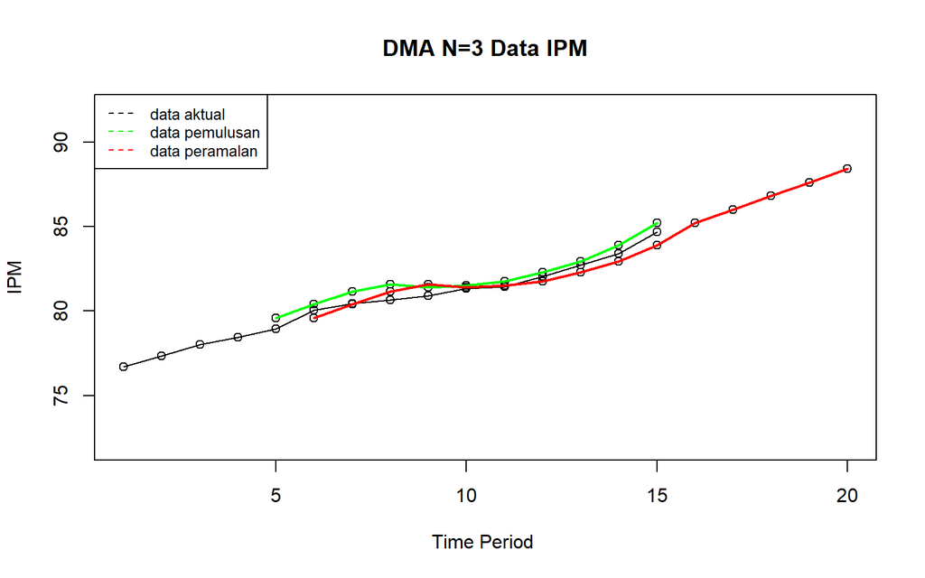

```r
#Plot time series
ts.plot(dt.gab[,1], xlab="Time Period ", ylab="IPM",
        main= "DMA N=3 Data IPM", ylim=c(72,92))
points(dt.gab[,1])
points(dt.gab[,3])
points(dt.gab[,6])
lines(dt.gab[,3],col="green",lwd=2)
lines(dt.gab[,6],col="red",lwd=2)
legend("topleft",c("data aktual","data pemulusan","data peramalan"),
       lty=8, col=c("black","green","red"), cex=0.8)
```

## 4.2 Akurasi DMA

```r
#Menghitung nilai keakuratan
error.dma = ipm.ts-dt.ramal[1:length(ipm.ts)]
SSE.dma = sum(error.dma[6:length(ipm.ts)]^2)
MSE.dma = mean(error.dma[6:length(ipm.ts)]^2)
MAPE.dma = mean(abs((error.dma[6:length(ipm.ts)]/ipm.ts[6:length(ipm.ts)])*100))

akurasi.dma <- matrix(c(SSE.dma, MSE.dma, MAPE.dma))
row.names(akurasi.dma)<- c("SSE", "MSE", "MAPE")
colnames(akurasi.dma) <- c("Akurasi m = 3")
akurasi.dma
```

```
##      Akurasi m = 3
## SSE      2.0770778
## MSE      0.2077078
## MAPE     0.4689919
```

## 4.3 Double Exponential Smoothing (DES)

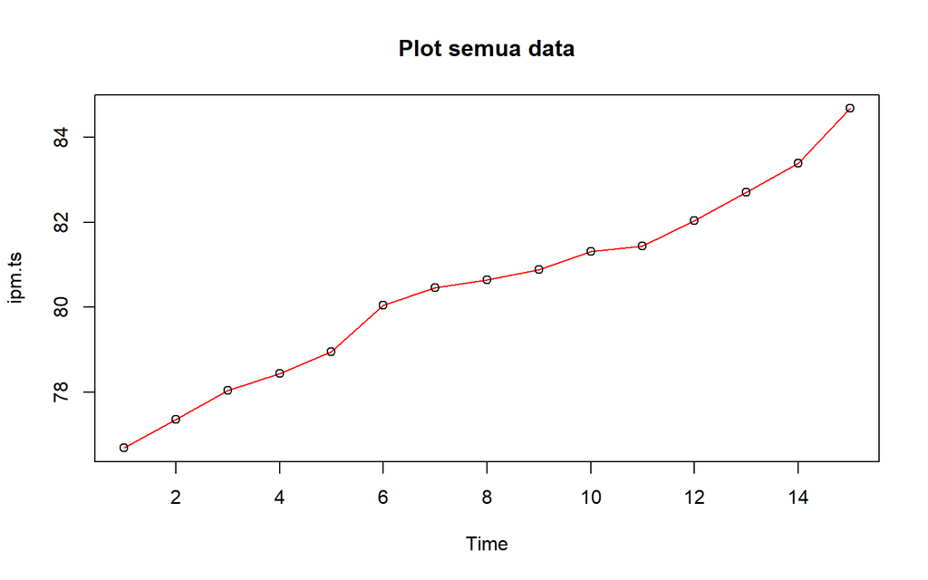

```r
#membagi training dan testing
training<-ipm[1:10,2]
testing<-ipm[11:15,2]

#data time series
training.ts<-ts(training)
testing.ts<-ts(testing,start=11)

#eksplorasi data
plot(ipm.ts, col="red",main="Plot semua data")
points(ipm.ts)
```

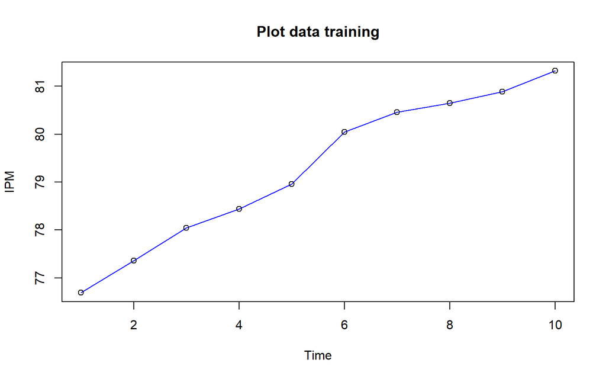

```r
plot(training.ts, col="blue",main="Plot data training")
points(training.ts)
```

```r
#Lamda dan gamma optimum
des.opt<- HoltWinters(training.ts, gamma = FALSE)
des.opt
```

```
## Holt-Winters exponential smoothing with trend and without seasonal component.
##
## Call:
## HoltWinters(x = training.ts, gamma = FALSE)
##
## Smoothing parameters:
##  alpha: 1
##  beta : 0.2338852
##  gamma: FALSE
##
## Coefficients:
##         [,1]
## a 81.3200000
## b  0.4557582
```

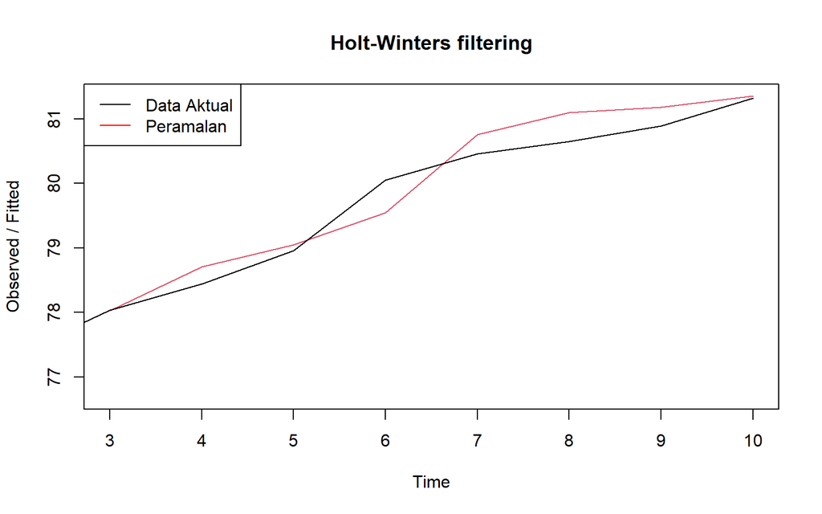

```r
plot(des.opt)
legend("topleft", c("Data Aktual", "Peramalan"), col = c("black", "red"),
       lty = c(1,1))
```

```r
#ramalan
ramalandesopt<- forecast::forecast(des.opt, h=5)
ramalandesopt
```

```
##    Point Forecast    Lo 80    Hi 80    Lo 95    Hi 95
## 11       81.77576 81.39992 82.15160 81.20096 82.35055
## 12       82.23152 81.63460 82.82843 81.31861 83.14442
## 13       82.68727 81.87449 83.50006 81.44422 83.93033
## 14       83.14303 82.10880 84.17727 81.56130 84.72476
## 15       83.59879 82.33434 84.86324 81.66498 85.53260
```

## 4.4 Akurasi DES Data Training

```r
ssedes.train<-des.opt$SSE
msedes.train<-ssedes.train/length(training.ts)
sisaandes<-ramalandesopt$residuals
head(sisaandes)
```

```
## Time Series:
## Start = 1
## End = 6
## Frequency = 1
##                x
## [1,]          NA
## [2,]          NA
## [3,]  0.01000000
## [4,] -0.27233885
## [5,] -0.08864281
## [6,]  0.50208943
```

```r
mapedes.train <- sum(abs(sisaandes[3:length(training.ts)]/training.ts[3:length(training.ts)])*100)/length(training.ts)

akurasides.opt <- matrix(c(ssedes.train,msedes.train,mapedes.train))
row.names(akurasides.opt)<- c("SSE", "MSE", "MAPE")
colnames(akurasides.opt) <- c("Akurasi lamda dan gamma optimum")
akurasides.opt
```

```
##      Akurasi lamda dan gamma optimum
## SSE                       0.70693042
## MSE                       0.07069304
## MAPE                      0.24220877
```

## 4.5 Akurasi Data Testing

```r
#Akurasi data testing
selisihdesopt<-ramalandesopt$mean-testing.ts
selisihdesopt
```

```
## Time Series:
## Start = 11
## End = 15
## Frequency = 1
##       testing.ts
## [1,]  0.32575819
## [2,]  0.19151638
## [3,] -0.02272543
## [4,] -0.24696724
## [5,] -1.08120904
```

```r
SSEtestingdesopt<-sum(selisihdesopt^2)
SSEtestingdesopt<-SSEtestingdesopt/length(testing.ts)
MAPEtestingdesopt<-sum(abs(selisihdesopt/testing.ts)*100)/length(testing.ts)

akurasiDesTesting <- matrix(c(SSEtestingdesopt,SSEtestingdesopt,MAPEtestingdesopt))
row.names(akurasiDesTesting)<- c("SSE", "MSE", "MAPE")
colnames(akurasiDesTesting) <- c("Akurasi lamda dan gamma optimum")
akurasiDesTesting
```

```
##      Akurasi lamda dan gamma optimum
## SSE                        0.2746638
## MSE                        0.2746638
## MAPE                       0.4467688
```

```r
cbind(akurasi.dma, akurasides.opt)
```

```
##      Akurasi m = 3 Akurasi lamda dan gamma optimum
## SSE      2.0770778                      0.70693042
## MSE      0.2077078                      0.07069304
## MAPE     0.4689919                      0.24220877
```

# 5 PERMODELAN REGRESI

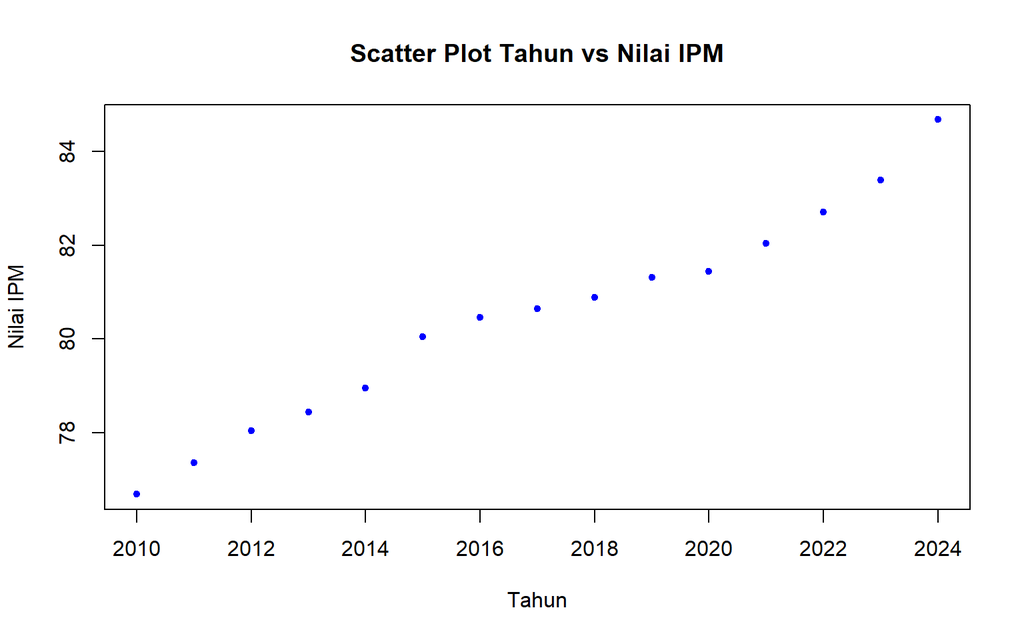

```r
#Eksplorasi Data
#Pembuatan Scatter Plot
plot(ipm$Tahun,ipm$IPM, pch = 20, col = "blue",
     main = "Scatter Plot Tahun vs Nilai IPM",
     xlab = "Tahun",
     ylab = "Nilai IPM")
```

```r
#Menampilkan Nilai Korelasi
cor(ipm$Tahun,ipm$IPM)
```

```
## [1] 0.9876656
```

Berdasarkan scatter plot di atas, terlihat adanya hubungan / korelasi positif antara peubah tahun dengan nilai IPM, terlihat titik-titik pada plot yang naik ke arah kanan atas. Hal tersebut juga diperkuat dengan hasil perhitungan aplikasi R di mana didapatkan nilai korelasi sebesar 0.9876656

```r
model <- lm(IPM ~ Tahun, data = ipm)
summary(model)
```

```
##
## Call:
## lm(formula = IPM ~ Tahun, data = ipm)
##
## Residuals:
##     Min      1Q  Median      3Q     Max
## -0.5285 -0.2141 -0.0864  0.1224  0.6972
##
## Coefficients:
##               Estimate Std. Error t value Pr(>|t|)
## (Intercept) -930.18574   44.43818  -20.93 2.14e-11 ***
## Tahun          0.50107    0.02203   22.74 7.46e-12 ***
## ---
## Signif. codes:  0 '***' 0.001 '**' 0.01 '*' 0.05 '.' 0.1 ' ' 1
##
## Residual standard error: 0.3687 on 13 degrees of freedom
## Multiple R-squared:  0.9755, Adjusted R-squared:  0.9736
## F-statistic: 517.3 on 1 and 13 DF,  p-value: 7.461e-12
```

$$\hat{yi} = -930.18574 + 0.50107xt$$

# 6 PENGUJIAN ASUMSI

## 6.1 Uji terhadap sisaan

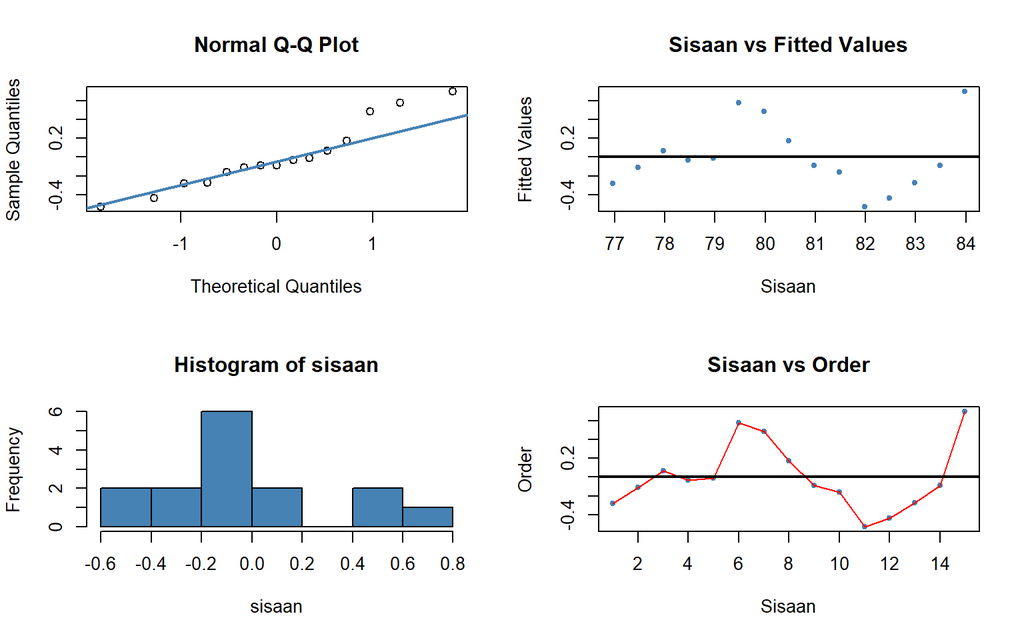

```r
sisaan<- residuals(model)
fitValue<- predict(model)

#Diagnostik dengan eksploratif
par(mfrow = c(2,2))
qqnorm(sisaan)
qqline(sisaan, col = "steelblue", lwd = 2)
plot(fitValue, sisaan, col = "steelblue", pch = 20, xlab = "Sisaan", ylab = "Fitted Values", main = "Sisaan vs Fitted Values")
abline(a = 0, b = 0, lwd = 2)
hist(sisaan, col = "steelblue")
plot(seq(1,15,1), sisaan, col = "steelblue", pch = 20, xlab = "Sisaan", ylab = "Order", main = "Sisaan vs Order")
lines(seq(1,15,1), sisaan, col = "red")
abline(a = 0, b = 0, lwd = 2)
```

Normal Q-Q Plot di atas menunjukkan bahwa sisaan cenderung tidak menyebar normal, begitu juga histogram dari sisaan menunjukkan demikian. Selanjutnya, dua plot di samping kanan digunakan untuk melihat autokorelasi. Plot Sisaan vs *Fitted Value* dan Plot Sisaan vs *Order* menunjukkan adanya pola pada sisaan. Untuk lebih lanjut akan digunakan uji formal melihat normalitas sisaan dan plot ACF dan PACF untuk melihat apakah ada autokorelasi atau tidak.

## 6.2 Uji Normalitas

```r
#Normalitas sisaan
shapiro.test(sisaan)
```

```
##
##  Shapiro-Wilk normality test
##
## data:  sisaan
## W = 0.93212, p-value = 0.2935
```

```r
ks.test(sisaan, "pnorm", mean=mean(sisaan), sd=sd(sisaan))
```

```
##
##  Exact one-sample Kolmogorov-Smirnov test
##
## data:  sisaan
## D = 0.18027, p-value = 0.6501
## alternative hypothesis: two-sided
```

$p-value > \alpha$ artinya sisaanya menyebar secara normal

## 6.3 Uji Autokorelasi

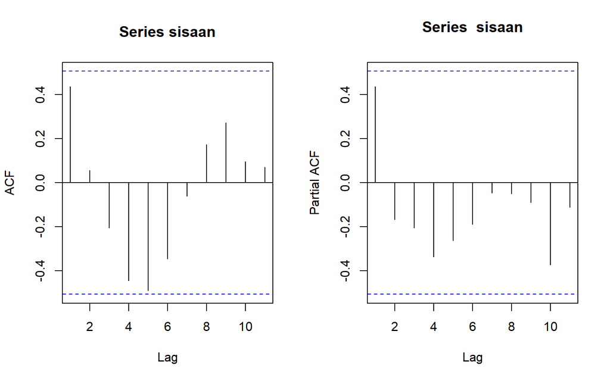

```r
#ACF dan PACF identifikasi autokorelasi
par(mfrow = c(1,2))
acf(sisaan)
pacf(sisaan)
```

Berdsaarkan plot ACF dan PACF, terlihat semua lag berada di rentang batas signifikan, sehingga dapat disimpulkan bahwa model regresi ini mengandung tidak autokorelasi.

```r
dwtest(model)
```

```
##
##  Durbin-Watson test
##
## data:  model
## DW = 0.8064, p-value = 0.001181
## alternative hypothesis: true autocorrelation is greater than 0
```

$p-value = 0.001181 < 0.05$ Artinya tolak H0, cukup bukti untuk mengatakan bahwa adanya autokorelasi. Oleh karena itu diperlukan adanya penanganan autokorelasi. Peanganan dilakukan menggunakan Cochrane-Orcutt dan Hildrhet-Lu

# 7 PENANGANAN AUTOKORELASI

## 7.1 Metode Cochrane-Orcutt

```r
model.co <- cochrane.orcutt(model)
model.co
```

```
## Cochrane-orcutt estimation for first order autocorrelation
##
## Call:
## lm(formula = IPM ~ Tahun, data = ipm)
##
##  number of interaction: 18
##  rho 0.656159
##
## Durbin-Watson statistic
## (original):    0.80640 , p-value: 1.181e-03
## (transformed): 1.16273 , p-value: 1.954e-02
##
##  coefficients:
## (Intercept)       Tahun
## -964.810560    0.518293
```

```r
dwtest(model.co)
```

```
##
##  Durbin-Watson test
##
## data:  model.co
## DW = 1.1627, p-value = 0.01954
## alternative hypothesis: true autocorrelation is greater than 0
```

$p-value$ sudah meningkat, tetapi masih belum cukup karena masih < 0.05 yang artinya tolak H0 dan masi terdapat autokorelasi.

### 7.1.1 Perhitungan Manual

```r
#rho optimum
rho<- model.co$rho
rho
```

```
## [1] 0.6561593
```

```r
#Transformasi Manual
ipm.trans<- ipm$IPM[-1]-ipm$IPM[-15]*rho
tahun.trans<- ipm$Tahun[-1]-ipm$Tahun[-15]*rho
modelCOmanual<- lm(ipm.trans~tahun.trans)
summary(modelCOmanual)
```

```
##
## Call:
## lm(formula = ipm.trans ~ tahun.trans)
##
## Residuals:
##      Min       1Q   Median       3Q      Max
## -0.49254 -0.16509 -0.04247  0.06256  0.66637
##
## Coefficients:
##               Estimate Std. Error t value Pr(>|t|)
## (Intercept) -331.74111   41.98947  -7.901 4.27e-06 ***
## tahun.trans    0.51829    0.06047   8.571 1.84e-06 ***
## ---
## Signif. codes:  0 '***' 0.001 '**' 0.01 '*' 0.05 '.' 0.1 ' ' 1
##
## Residual standard error: 0.3136 on 12 degrees of freedom
## Multiple R-squared:  0.8596, Adjusted R-squared:  0.8479
## F-statistic: 73.46 on 1 and 12 DF,  p-value: 1.844e-06
```

```r
b0bintang <- modelCOmanual$coefficients[-2]
b0 <- b0bintang/(1-rho)
b1 <- modelCOmanual$coefficients[-1]
b0
```

```
## (Intercept)
##   -964.8106
```

```r
b1
```

```
## tahun.trans
##   0.5182931
```

```r
# uji autokorelasi
dwtest(modelCOmanual)
```

```
##
##  Durbin-Watson test
##
## data:  modelCOmanual
## DW = 1.1627, p-value = 0.01954
## alternative hypothesis: true autocorrelation is greater than 0
```

Hasil dari Durbit-Watson test $p-value =0.01954 < 0.05$ artinya autokorelasi tetap tidak tertangani menggunakan metode cochrane-orcutt

## 7.2 Metode Hildreth-Lu

Selanjutnta menggunakan metode keuda dengan mencari nilai SSE terkecil

```r
#Penanganan Autokorelasi Hildreth lu
# Hildreth-Lu
hildreth.lu.func<- function(r, model){
  x <- model.matrix(model)[,-1]
  y <- model.response(model.frame(model))
  n <- length(y)
  t <- 2:n
  y <- y[t]-r*y[t-1]
  x <- x[t]-r*x[t-1]

  return(lm(y~x))
}

#Pencariab rho yang meminimumkan SSE
r <- c(seq(0.1,0.9, by= 0.1))
tab <- data.frame("rho" = r, "SSE" = sapply(r, function(i){deviance(hildreth.lu.func(i, model))}))
round(tab, 4)
```

```
##   rho    SSE
## 1 0.1 1.5286
## 2 0.2 1.4146
## 3 0.3 1.3231
## 4 0.4 1.2542
## 5 0.5 1.2078
## 6 0.6 1.1839
## 7 0.7 1.1825
## 8 0.8 1.2036
## 9 0.9 1.2472
```

```r
#Rho optimal di sekitar 0.4
rOpt <- seq(0.6,0.7, by= 0.001)
tabOpt <- data.frame("rho" = rOpt, "SSE" = sapply(rOpt, function(i){deviance(hildreth.lu.func(i, model))}))
head(tabOpt[order(tabOpt$SSE),])
```

```
##      rho      SSE
## 57 0.656 1.180303
## 58 0.657 1.180303
## 56 0.655 1.180304
## 59 0.658 1.180306
## 55 0.654 1.180308
## 60 0.659 1.180312
```

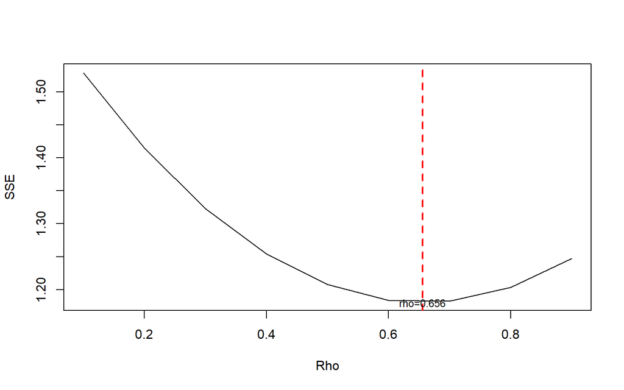

```r
#Grafik SSE optimum
par(mfrow = c(1,1))
plot(tab$SSE ~ tab$rho , type = "l", xlab = "Rho", ylab = "SSE")
abline(v = tabOpt[tabOpt$SSE==min(tabOpt$SSE),"rho"], lty = 2, col="red",lwd=2)
text(x=0.656, y=1.180303, labels = "rho=0.656", cex = 0.8)
```

### 7.2.1 Permodelan Regresi

```r
#Model terbaik
modelHL <- hildreth.lu.func(0.656, model)
summary(modelHL)
```

```
##
## Call:
## lm(formula = y ~ x)
##
## Residuals:
##      Min       1Q   Median       3Q      Max
## -0.49255 -0.16513 -0.04250  0.06261  0.66638
##
## Coefficients:
##               Estimate Std. Error t value Pr(>|t|)
## (Intercept) -331.88192   41.98944  -7.904 4.25e-06 ***
## x              0.51827    0.06044   8.574 1.84e-06 ***
## ---
## Signif. codes:  0 '***' 0.001 '**' 0.01 '*' 0.05 '.' 0.1 ' ' 1
##
## Residual standard error: 0.3136 on 12 degrees of freedom
## Multiple R-squared:  0.8597, Adjusted R-squared:  0.848
## F-statistic: 73.52 on 1 and 12 DF,  p-value: 1.836e-06
```

$$yi = -331.881 + 0.51xt$$

Berdasarkan ringkasan model, uji F menghasilkan p-value < α (5%), yang berarti setidaknya ada satu variabel yang berpengaruh signifikan. Karena model ini hanya menggunakan satu variabel, hasil tersebut menegaskan bahwa variabel prediktor (termasuk intersep) memang signifikan. Uji t parsial pada intersep maupun koefisien regresi juga menunjukkan p-value < α (5%), sehingga keduanya nyata pada taraf 5%. Namun, model tetap perlu ditransformasi kembali agar dapat diinterpretasikan dengan tepat. Sementara itu, pengujian asumsi autokorelasi dilakukan pada model hasil transformasi, sehingga model yang dianggap valid adalah model yang sudah memenuhi asumsi tersebut.

```r
#Transformasi Balik
cat("y = ", coef(modelHL)[1]/(1-0.656), "+", coef(modelHL)[2],"x", sep = "")
```

```
## y = -964.773+0.5182745x
```

```r
#Deteksi autokorelasi
dwtest(modelHL)
```

```
##
##  Durbin-Watson test
##
## data:  modelHL
## DW = 1.1627, p-value = 0.01953
## alternative hypothesis: true autocorrelation is greater than 0
```

Ternyata, setelah dilakukan penanganan menggunakan methode Hildreth-Lu, $p-value$ masih menunjukkan nilai $< 0.05$ yang artinya autokorelasi masih belum dapat tertangani. Sehingga tidak ada model yang dapat dikatakan valid.

# 8 PERBANDINGAN MODEL

```r
#Perbandingan
sseModelawal <- anova(model)$`Sum Sq`[-1]
sseModelCO <- anova(modelCOmanual)$`Sum Sq`[-1]
sseModelHL <- anova(modelHL)$`Sum Sq`[-1]
mseModelawal <- sseModelawal/length(ipm)
mseModelCO <- sseModelCO/length(ipm)
mseModelHL <- sseModelHL/length(ipm)
akurasi <- matrix(c(sseModelawal,sseModelCO,sseModelHL,
                    mseModelawal,mseModelCO,mseModelHL),nrow=2,ncol=3,byrow = T)
colnames(akurasi) <- c("Model Awal", "Model Cochrane-Orcutt", "Model Hildreth-Lu")
row.names(akurasi) <- c("SSE","MSE")
akurasi
```

```
##     Model Awal Model Cochrane-Orcutt Model Hildreth-Lu
## SSE   1.766852             1.1803026         1.1803026
## MSE   0.883426             0.5901513         0.5901513
```

Setelah dilakukan penanganan, meskipun permasalahan autokorelasi belum sepenuhnya teratasi, terlihat adanya penurunan nilai SSE dan MSE. Hal ini menunjukkan bahwa kualitas model meningkat, di mana model hasil penanganan mampu memberikan estimasi yang lebih akurat dibandingkan dengan model awal.